# projet RDSM

En revanche, le taux d’O3 et l’humidité semble corrélés plus négativement comme nous l’avions vu précédemment. Ici, le taux d’O3 est toujours plus élevé dans la journée mais coïncide ici avec une humidité plus faible, qui semble augmenter pendant la nuit.

Le lien entre O3 et NO semble complexe mais plutôt décroissant, on constate aussi que les taux de NO tendent à être plus important en début de matinée ou en soirée.

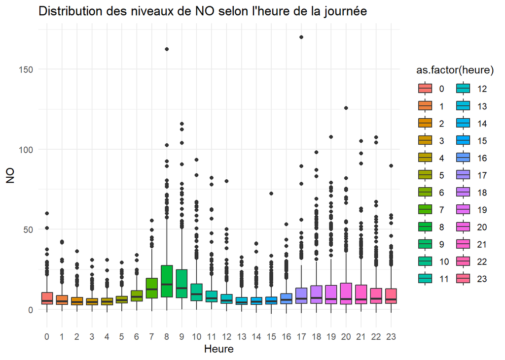

```r
# Boxplot d'O3 par heure
ggplot(df, aes(x = as.factor(heure), y = NO, fill = as.factor(heure))) +
  geom_boxplot() +
  ggtitle("Distribution des niveaux de NO selon l'heure de la journée") +
  theme_minimal() +
  labs(x = "Heure", y = "NO")
```

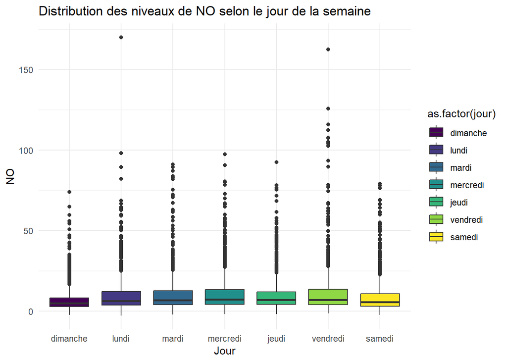

```r
# Boxplot de NO par jour de la semaine
ggplot(df, aes(x = as.factor(jour), y = NO, fill = as.factor(jour))) +
  geom_boxplot() +
  ggtitle("Distribution des niveaux de NO selon le jour de la semaine") +
  theme_minimal() +
  labs(x = "Jour", y = "NO")
```

Concernant les heures de la journées, nous pouvons voir pour la variable NO qu’une augmentation se fait autour de 8h et autour de 20h, sûrement dû à l’activité humaine. Il semble y avoir beaucoup de valeurs abberantes mais elles suivent le même schéma que les autres valeurs.

En nous intéressant aux jours de la semaine, les différences sont moins importantes mais on constate malgré tout une baisse le samedi et une baisse plus importante encore le dimanche. On retrouve encore une quantité importante de valeurs aberrantes qui suivent le même type de répartition. Cependant, il existe 2 valeurs vraiment différente, une le lundi et une le vendredi. Etant particulièrement éloigné des autres, elles peuvent avoir subit un problème au moment de la mesure où elles peuvent être dpu à un évenement ponctuel particulièrement polluant dans la ville.

**Conclusion**

En conclusion, cette analyse multivariée a mis en évidence des relations significatives entre les facteurs météorologiques et les niveaux de pollution atmosphérique. Les résultats montrent que l’ozone (O3) est positivement corrélé à la température et au vent, tandis qu’il est négativement lié au dioxyde d’azote (NO) et à l’humidité. Ces relations reflètent les mécanismes chimiques et physiques influençant la concentration des polluants, ainsi que leur dépendance aux conditions climatiques.

Les analyses temporelles révèlent une dynamique quotidienne, avec des niveaux d’O3 plus faibles la nuit, augmentant durant la journée avec la température. En revanche, les niveaux de NO montrent des pics matinaux et nocturnes, associés aux périodes de forte circulation automobile. Les variations hebdomadaires indiquent une baisse de la pollution pendant le week-end, en raison de la réduction des activités humaines.

Ces résultats soulignent l’importance des facteurs climatiques et des comportements humains dans la qualité de l’air. Ils peuvent être utilisés pour prévoir les périodes critiques et informer des stratégies de gestion adaptées, comme limiter les émissions aux heures ou aux jours les plus sensibles. Cela constitue une base pour améliorer la qualité de vie en réduisant l’impact de la pollution sur la santé et l’environnement.